# Lab4

**Dragos Ailoae**

Applied Statistics and Econometrics 2

2022-02-17

## Intro to Panel Data Analysis with R

### The Fixed Effects (FE) Model

To illustrate the fixed effects model we will use the "Fatalities" dataset in the AER package (details [here](https://rdrr.io/cran/AER/man/Fatalities.html)) and try to understand the relationship between traffic fatalities and alcohol taxes in the United States.

Let's begin by loading some necessary packages and taking a peek at the dataset structure:

```r
rm(list=ls())    # Removes all items in Environment!
options(repr.plot.width = 5, repr.plot.height = 5)
# LOAD PACKAGES:
packages <- c("knitr","tidyverse","plm","modelsummary","AER")
# Loop though vector and load respective packages:
zzz <- lapply(packages, function(xxx) suppressMessages(require(xxx,
               character.only = TRUE, quietly=TRUE, warn.conflicts = FALSE)))  # quiet no warnings
```

```r
data(Fatalities)
str(Fatalities)
```

```
'data.frame':	336 obs. of  34 variables:
 $ state       : Factor w/ 48 levels "al","az","ar",..: 1 1 1 1 1 1 1 2 2 2 ...
 $ year        : Factor w/ 7 levels "1982","1983",..: 1 2 3 4 5 6 7 1 2 3 ...
 $ spirits     : num  1.37 1.36 1.32 1.28 1.23 ...
 $ unemp       : num  14.4 13.7 11.1 8.9 9.8 ...
 $ income      : num  10544 10733 11109 11333 11662 ...
 $ emppop      : num  50.7 52.1 54.2 55.3 56.5 ...
 $ beertax     : num  1.54 1.79 1.71 1.65 1.61 ...
 $ baptist     : num  30.4 30.3 30.3 30.3 30.3 ...
 $ mormon      : num  0.328 0.343 0.359 0.376 0.393 ...
 $ drinkage    : num  19 19 19 19.7 21 ...
 $ dry         : num  25 23 24 23.6 23.5 ...
 $ youngdrivers: num  0.212 0.211 0.211 0.211 0.213 ...
 $ miles       : num  7234 7836 8263 8727 8953 ...
 $ breath      : Factor w/ 2 levels "no","yes": 1 1 1 1 1 1 1 1 1 1 ...
```

[output cut: 20 more lines]

We find that the dataset consists of 336 observations on 34 variables. Notice that the variable "state" is a factor variable with 48 levels (one for each of the 48 contiguous federal states of the U.S.). The variable "year" is also a factor variable that has 7 levels identifying the time period when the observation was made. This gives us 7$\times$48=336 observations in total. Since all variables are observed for all entities and over all time periods, the panel is **balanced**. If there were missing data for at least one entity in at least one time period we would call the panel **unbalanced.**

### First steps: OLS for a specific year

Let's start by estimating simple regressions using data for years 1982 and 1988 that model the relationship between beer tax (adjusted for 1988 dollars) and the traffic fatality rate, measured as the number of fatalities per 10000 inhabitants. Afterwards, we plot the data and add the corresponding estimated regression functions.

```r
# define the fatality rate
Fatalities$fatal_rate <- Fatalities$fatal / Fatalities$pop * 10000

# subset the data
Fatalities1982 <- subset(Fatalities, year == "1982")
Fatalities1988 <- subset(Fatalities, year == "1988")

# estimate simple regression models using 1982 and 1988 data
fatal1982_mod <- lm(fatal_rate ~ beertax, data = Fatalities1982)
fatal1988_mod <- lm(fatal_rate ~ beertax, data = Fatalities1988)

# print summary using robust standard errors
coeftest(fatal1982_mod, vcov = vcovHC, type = "HC1")
```

```
t test of coefficients:

            Estimate Std. Error t value Pr(>|t|)
(Intercept)  2.01038    0.14957 13.4408   <2e-16 ***
beertax      0.14846    0.13261  1.1196   0.2687
---
Signif. codes:  0 '***' 0.001 '**' 0.01 '*' 0.05 '.' 0.1 ' ' 1
```

```r
# print summary using robust standard errors
coeftest(fatal1988_mod, vcov = vcovHC, type = "HC1")
```

```
t test of coefficients:

            Estimate Std. Error t value  Pr(>|t|)
(Intercept)  1.85907    0.11461 16.2205 < 2.2e-16 ***
beertax      0.43875    0.12786  3.4314  0.001279 **
---
Signif. codes:  0 '***' 0.001 '**' 0.01 '*' 0.05 '.' 0.1 ' ' 1
```

The estimated regression functions are $$ \begin{array}{ll} \widehat{\text { FatalityRate }} & =\underset{(0.15)}{2.01}+\underset{(0.13)}{0.15} \times \widehat{\text { BeerTax }} \quad(1982 \text { data }), \\ \widehat{\text { Fatality Rate }} & =\underset{(0.11)}{1.86}+\underset{(0.13)}{0.44} \times \widehat{\text { BeerTax }} \quad(1988 \text { data }) . \end{array} $$

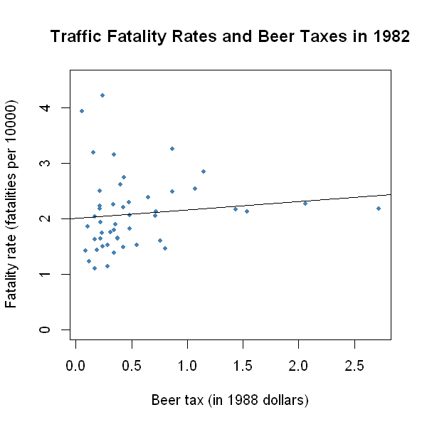

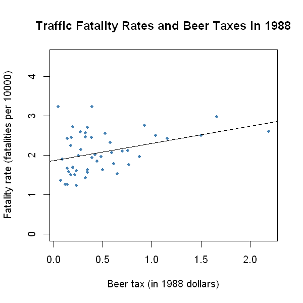

```r
# plot the observations and add the estimated regression line for 1982 data
plot(x = Fatalities1982$beertax,
     y = Fatalities1982$fatal_rate,
     xlab = "Beer tax (in 1988 dollars)",
     ylab = "Fatality rate (fatalities per 10000)",
     main = "Traffic Fatality Rates and Beer Taxes in 1982",
     ylim = c(0, 4.5),
     pch = 20,
     col = "steelblue")
abline(fatal1982_mod, lwd = 1.5)
# plot observations and add estimated regression line for 1988 data
plot(x = Fatalities1988$beertax,
     y = Fatalities1988$fatal_rate,
     xlab = "Beer tax (in 1988 dollars)",
     ylab = "Fatality rate (fatalities per 10000)",
     main = "Traffic Fatality Rates and Beer Taxes in 1988",
     ylim = c(0, 4.5),
     pch = 20,
     col = "steelblue")

abline(fatal1988_mod, lwd = 1.5)
```

This could be corrected for using a multiple regression approach. However, this cannot account for omitted **unobservable factors** that differ from state to state but can be assumed to be constant over the observation span, e.g., **the populations’ attitude towards drunk driving**. As shown in the next section, panel data allow us to hold such factors constant.

### Fixed Effects Model: Dummy vs. Demeaned Data Approach

The fixed effects regression model is \begin{equation} Y_{i t}=\beta_{1} X_{1, i t}+\cdots+\beta_{k} X_{k, i t}+\alpha_{i}+u_{i t} \end{equation}

with $i=1, \ldots, n$ and $t=1, \ldots, T$. The $\alpha_{i}$ are entity-specific intercepts that capture heterogeneity across entities.

An equivalent representation of this model is given by \begin{equation} Y_{i t}=\beta_{0}+\beta_{1} X_{1, i t}+\cdots+\beta_{k} X_{k, i t}+\gamma_{2} D 2_{i}+\gamma_{3} D 3_{i}+\cdots+\gamma_{n} D n_{i}+u_{i t} \end{equation} where the $D 2_{i}, D 3_{i}, \ldots, D n_{i}$ are dummy variables.

Software packages use a so-called "entity-demeaned" OLS algorithm which is computationally more efficient than estimating regression models with $k+n$ regressors as needed for the above models.

Taking averages on both sides of (1), we obtain $$ \begin{aligned} \frac{1}{T} \sum_{t=1}^{T} Y_{i t} &=\beta_{1} \frac{1}{T} \sum_{t=1}^{T} X_{i t}+\frac{1}{T} \sum_{t=1}^{T} a_{i}+\frac{1}{T} \sum_{t=1}^{T} u_{i t} \\ \bar{Y}_i &=\beta_{1} \bar{X}_{i}+\alpha_{i}+\bar{u}_{i} \\ \end{aligned} $$

Subtraction from (1) yields

$$ \begin{aligned} Y_{i t}-\bar{Y}_{i} &=\beta_{1}\left(X_{i t}-\bar{X}_{i}\right)+\left(u_{i t}-\bar{u}_{i}\right) \\ \tilde{Y}_{i t} &=\beta_{1} \tilde{X}_{i t}+\tilde{u}_{i t} \end{aligned} $$

thus getting rid of the $\alpha_i$ terms. In this model, the OLS estimate of the parameter of interest $\beta_{1}$ is equal to the estimate obtained using (1) without the need to estimate $n-1$ dummies and an intercept. We conclude that there are two ways of estimating $\beta_{1}$ in the fixed effects regression:

1. OLS of the dummy regression model
2. OLS using the entity demeaned data

### Application using lm() and dummy variables (LSDV Estimator)

The simple fixed effects model for estimation of the relation between traffic fatality rates and the beer taxes is

$$ \text { FatalityRate }_{i t}=\beta_{1} \text { BeerTax }_{i t}+\text { StateFixedEffects }+u_{i t} $$

a regression of the traffic fatality rate on beer tax and 48 binary regressors $-$ one for each federal state. We can simply use the function $\operatorname{lm}()$ to obtain an estimate of $\beta_{1}$.

```r
fatal_fe_lm_mod <- lm(fatal_rate ~ beertax + state - 1,
                      data = Fatalities)  # Note the -1 eliminates the constant to avoid perfect collinearity
fatal_fe_lm_mod
```

```
Call:
lm(formula = fatal_rate ~ beertax + state - 1, data = Fatalities)

Coefficients:
beertax  stateal  stateaz  statear  stateca  stateco  statect  statede
-0.6559   3.4776   2.9099   2.8227   1.9682   1.9933   1.6154   2.1700
statefl  statega  stateid  stateil  statein  stateia  stateks  stateky
 3.2095   4.0022   2.8086   1.5160   2.0161   1.9337   2.2544   2.2601
statela  stateme  statemd  statema  statemi  statemn  statems  statemo
 2.6305   2.3697   1.7712   1.3679   1.9931   1.5804   3.4486   2.1814
statemt  statene  statenv  statenh  statenj  statenm  stateny  statenc
 3.1172   1.9555   2.8769   2.2232   1.3719   3.9040   1.2910   3.1872
statend  stateoh  stateok  stateor  statepa  stateri  statesc  statesd
 1.8542   1.8032   2.9326   2.3096   1.7102   1.2126   4.0348   2.4739
statetn  statetx  stateut  statevt  stateva  statewa  statewv  statewi
 2.6020   2.5602   2.3137   2.5116   2.1874   1.8181   2.5809   1.7184
statewy
 3.2491
```

Remember that regressing Y on a constant such as the state indicator dummy, is equivalent to finding the mean of Y. This is why the regression constant is sometimes called "the bias" since the explanatory data variation occurs relative to this fixed ("bias") level.

See demo below which produces the average of numbers 1 to 5 using lm().

```r
r <- 1:5
fit <- lm(r ~ 1)
summary(fit)
```

```
Call:
lm(formula = r ~ 1)

Residuals:
 1  2  3  4  5
-2 -1  0  1  2

Coefficients:
            Estimate Std. Error t value Pr(>|t|)
(Intercept)   3.0000     0.7071   4.243   0.0132 *
---
Signif. codes:  0 '***' 0.001 '**' 0.01 '*' 0.05 '.' 0.1 ' ' 1

Residual standard error: 1.581 on 4 degrees of freedom
```

This is equivalent to:

```r
mean(r)
sd(r)/sqrt(length(r))
t.test(r)
```

3

0.707106781186548

```
	One Sample t-test

data:  r
t = 4.2426, df = 4, p-value = 0.01324
alternative hypothesis: true mean is not equal to 0
95 percent confidence interval:
 1.036757 4.963243
sample estimates:
mean of x
        3
```

### Application using lm() and demeaned variables

As discussed in the previous section, it is also possible to estimate $\beta_{1}$ by applying OLS to the demeaned data, that is, to run the regression $$ \widetilde{\text { FatalityRate }}=\beta_{1} \widetilde{\text {BeerTax}_{i t}}+u_{i t} . $$

The function ave() is convenient for computing group averages. We use it to obtain state specific averages of the fatality rate and the beer tax.

```r
# obtain demeaned data
Fatalities_demeaned <- with(Fatalities,
            data.frame(fatal_rate = fatal_rate - ave(fatal_rate, state),
            beertax = beertax - ave(beertax, state)))
# estimate the regression
summary(lm(fatal_rate ~ beertax - 1, data = Fatalities_demeaned))
```

```
Call:
lm(formula = fatal_rate ~ beertax - 1, data = Fatalities_demeaned)

Residuals:
     Min       1Q   Median       3Q      Max
-0.58696 -0.08284 -0.00127  0.07955  0.89780

Coefficients:
        Estimate Std. Error t value Pr(>|t|)
beertax  -0.6559     0.1739  -3.772 0.000191 ***
---
Signif. codes:  0 '***' 0.001 '**' 0.01 '*' 0.05 '.' 0.1 ' ' 1

Residual standard error: 0.1757 on 335 degrees of freedom
Multiple R-squared:  0.04074,	Adjusted R-squared:  0.03788
F-statistic: 14.23 on 1 and 335 DF,  p-value: 0.0001913
```

### Application using plm()

Alternatively we may use plm() from the PLM package. Just like lm(), we have to specify the regression formula and the data to be used in our call of plm().

Additionally, it is required to pass a vector of names of entity and time ID variables to the argument index. For Fatalities, the ID variable for entities is named state and the time id variable is year. Alternately this can be done with the panel.frame() function. Since the fixed effects estimator is also called the within estimator, we set model = “within”.

Finally, the function coeftest() allows to obtain inference based on robust standard errors.

```r
# estimate the fixed effects regression with plm()
fatal_fe_mod <- plm(fatal_rate ~ beertax,
                    data = Fatalities,
                    index = c("state", "year"),
                    model = "within")

# print summary using robust standard errors
coeftest(fatal_fe_mod, vcov. = vcovHC, type = "HC1")
```

```
t test of coefficients:

        Estimate Std. Error t value Pr(>|t|)
beertax -0.65587    0.28880  -2.271  0.02388 *
---
Signif. codes:  0 '***' 0.001 '**' 0.01 '*' 0.05 '.' 0.1 ' ' 1
```

The estimated coefficient is again $-0.6559 .$ Note that $p 1 m()$ uses the entity-demeaned OLS algorithm and thus does not report dummy coefficients. The estimated regression function is $$ \widehat{\text { Fatality Rate }}=-\underset{(0.29)}{0.66} \times \widehat{\text { BeerTax }}+\text { StateFixedEffects } $$ The coefficient on BeerTax is negative and significant. The interpretation is that the estimated reduction in traffic fatalities due to an increase in the real beer tax by $\$ 1$ is $0.66$ per 10000 people, which is still pretty high. Although including state fixed effects eliminates the risk of a bias due to omitted factors that vary across states but not over time, we suspect that there are other omitted variables that vary over time and thus cause a bias.

### Regression with Time Fixed Effects

Controlling for variables that are constant across entities but vary over time can be done by including time fixed effects. If there are only time fixed effects, the fixed effects regression model becomes $$ Y_{i t}=\beta_{0}+\beta_{1} X_{i t}+\delta_{2} B 2_{t}+\cdots+\delta_{T} B T_{t}+u_{i t} $$ where only $T-1$ dummies are included ( $B 1$ is omitted) since the model includes an intercept. This model eliminates omitted variable bias caused by excluding unobserved variables that evolve over time but are constant across entities. In some applications it is meaningful to include both entity and time fixed effects. The entity and time fixed effects model is $$ Y_{i t}=\beta_{0}+\beta_{1} X_{i t}+\gamma_{2} D 2_{i}+\cdots+\gamma_{n} D T_{i}+\delta_{2} B 2_{t}+\cdots+\delta_{T} B T_{t}+u_{i t} $$ The combined model allows to eliminate bias from unobservables that change over time but are constant over entities and it controls for factors that differ across entities but are constant over time. Such models can be estimated using the OLS algorithm that is implemented in R.

```r
# estimate a combined time and entity fixed effects regression model

# via lm()
fatal_tefe_lm_mod <- lm(fatal_rate ~ beertax + state + year - 1, data = Fatalities)
fatal_tefe_lm_mod
```

```
Call:
lm(formula = fatal_rate ~ beertax + state + year - 1, data = Fatalities)

Coefficients:
 beertax   stateal   stateaz   statear   stateca   stateco   statect   statede
-0.63998   3.51137   2.96451   2.87284   2.02618   2.04984   1.67125   2.22711
 statefl   statega   stateid   stateil   statein   stateia   stateks   stateky
 3.25132   4.02300   2.86242   1.57287   2.07123   1.98709   2.30707   2.31659
 statela   stateme   statemd   statema   statemi   statemn   statems   statemo
 2.67772   2.41713   1.82731   1.42335   2.04488   1.63488   3.49146   2.23598
 statemt   statene   statenv   statenh   statenj   statenm   stateny   statenc
 3.17160   2.00846   2.93322   2.27245   1.43016   3.95748   1.34849   3.22630
 statend   stateoh   stateok   stateor   statepa   stateri   statesc   statesd
 1.90762   1.85664   2.97776   2.36597   1.76563   1.26964   4.06496   2.52317
 statetn   statetx   stateut   statevt   stateva   statewa   statewv   statewi
 2.65670   2.61282   2.36165   2.56100   2.23618   1.87424   2.63364   1.77545
 statewy  year1983  year1984  year1985  year1986  year1987  year1988
 3.30791  -0.07990  -0.07242  -0.12398  -0.03786  -0.05090  -0.05180
```

And via plm()

```r
# via plm()
fatal_tefe_mod <- plm(fatal_rate ~ beertax,
                      data = Fatalities,
                      index = c("state", "year"),
                      model = "within",
                      effect = "twoways")

coeftest(fatal_tefe_mod, vcov = vcovHC, type = "HC1")
```

```
t test of coefficients:

        Estimate Std. Error t value Pr(>|t|)
beertax -0.63998    0.35015 -1.8277  0.06865 .
---
Signif. codes:  0 '***' 0.001 '**' 0.01 '*' 0.05 '.' 0.1 ' ' 1
```

### Adding Covariates to Panel Regression: Drunk Driving Laws and Traffic Deaths

There are two major sources of omitted variable bias that are not accounted for by all of the models of the relation between traffic fatalities and beer taxes that we have considered so far: economic conditions and driving laws. Fortunately, Fatalities has data on state-specific legal drinking age (drinkage), punishment (jail, service) and various economic indicators like unemployment rate (unemp) and per capita income (income). We may use these covariates to extend the preceding analysis. These covariates are defined as follows:

- unemp: a numeric variable stating the state specific unemployment rate.
- $\log$ (income): the logarithm of real per capita income (in prices of 1988).
- miles: the state average miles per driver.
- drinkage: the state specific minimum legal drinking age.
- drinkagc: a discretized version of drinkage that classifies states into four categories of minimal drinking age; $18,19,20,21$ and older. $R$ denotes this as $[18,19),[19,20),[20,21)$ and $[21,22] .$ These categories are included as dummy regressors where $[21,22]$ is chosen as the reference category.
- punish: a dummy variable with levels yes and no that measures if drunk driving is severely punished by mandatory jail time or mandatory community service (first conviction).

At first, we define the variables as above:

```r
# discretize the minimum legal drinking age
Fatalities$drinkagec <- cut(Fatalities$drinkage,
                            breaks = 18:22,
                            include.lowest = TRUE,
                            right = FALSE)

# set minimum drinking age [21, 22] to be the baseline level
Fatalities$drinkagec <- relevel(Fatalities$drinkagec, "[21,22]")

# mandadory jail or community service?
Fatalities$punish <- with(Fatalities, factor(jail == "yes" | service == "yes",
                                             labels = c("no", "yes")))

# the set of observations on all variables for 1982 and 1988
Fatalities_1982_1988 <- Fatalities[with(Fatalities, year == 1982 | year == 1988), ]
```

Next, we estimate all seven models using plm().

```r
# estimate all seven models
fatalities_mod1 <- lm(fatal_rate ~ beertax, data = Fatalities)

fatalities_mod2 <- plm(fatal_rate ~ beertax + state, data = Fatalities)

fatalities_mod3 <- plm(fatal_rate ~ beertax + state + year,
                       index = c("state","year"),
                       model = "within",
                       effect = "twoways",
                       data = Fatalities)

fatalities_mod4 <- plm(fatal_rate ~ beertax + state + year + drinkagec
                       + punish + miles + unemp + log(income),
                       index = c("state", "year"),
                       model = "within",
                       effect = "twoways",
                       data = Fatalities)

fatalities_mod5 <- plm(fatal_rate ~ beertax + state + year + drinkagec
                       + punish + miles,
                       index = c("state", "year"),
                       model = "within",
                       effect = "twoways",
                       data = Fatalities)

fatalities_mod6 <- plm(fatal_rate ~ beertax + year + drinkage
                       + punish + miles + unemp + log(income),
                       index = c("state", "year"),
                       model = "within",
                       effect = "twoways",
                       data = Fatalities)

fatalities_mod7 <- plm(fatal_rate ~ beertax + state + year + drinkagec
                       + punish + miles + unemp + log(income),
                       index = c("state", "year"),
                       model = "within",
                       effect = "twoways",
                       data = Fatalities_1982_1988)
```

To present the models side by side we can use the modelsummary() function for a nicely formated table:

```r
models <- list(fatalities_mod1, fatalities_mod2, fatalities_mod3,
               fatalities_mod4, fatalities_mod5, fatalities_mod6, fatalities_mod7)

modelsummary(models,
        vcov = "HC1",
        stars = TRUE,
        title ="Panel Regression Models of Traffic Fatalities due to Drunk Driving") %>%
            as.character  %>% IRdisplay::display_html()
```

Panel Regression Models of Traffic Fatalities due to Drunk Driving

|  | Model 1 | Model 2 | Model 3 | Model 4 | Model 5 | Model 6 | Model 7 |
| --- | --- | --- | --- | --- | --- | --- | --- |
| (Intercept) | 1.853*** |  |  |  |  |  |  |
|  | (0.047) |  |  |  |  |  |  |
| beertax | 0.365*** | −0.656* | −0.640+ | −0.445 | −0.690* | −0.456 | −0.926** |
|  | (0.053) | (0.289) | (0.350) | (0.291) | (0.345) | (0.301) | (0.337) |
| drinkagec[18,19) |  |  |  | 0.028 | −0.010 |  | 0.037 |
|  |  |  |  | (0.068) | (0.081) |  | (0.101) |
| drinkagec[19,20) |  |  |  | −0.018 | −0.076 |  | −0.065 |
|  |  |  |  | (0.049) | (0.066) |  | (0.097) |
| drinkagec[20,21) |  |  |  | 0.032 | −0.100+ |  | −0.113 |
|  |  |  |  | (0.050) | (0.055) |  | (0.123) |
| punishyes |  |  |  | 0.038 | 0.085 | 0.039 | 0.089 |
|  |  |  |  | (0.101) | (0.109) | (0.101) | (0.161) |
| miles |  |  |  | 0.000 | 0.000+ | 0.000 | 0.000* |
|  |  |  |  | (0.000) | (0.000) | (0.000) | (0.000) |
| unemp |  |  |  | −0.063*** |  | −0.063*** | −0.091*** |
|  |  |  |  | (0.013) |  | (0.013) | (0.021) |
| log(income) |  |  |  | 1.816** |  | 1.786** | 0.996 |
|  |  |  |  | (0.624) |  | (0.631) | (0.666) |
| drinkage |  |  |  |  |  | −0.002 |  |
|  |  |  |  |  |  | (0.021) |  |
| Num.Obs. | 336 | 336 | 336 | 335 | 335 | 335 | 95 |
| R2 | 0.093 | 0.041 | 0.036 | 0.360 | 0.066 | 0.357 | 0.659 |
| R2 Adj. | 0.091 | −0.120 | −0.149 | 0.217 | −0.134 | 0.219 | 0.157 |
| AIC | 548.1 |  |  |  |  |  |  |
| BIC | 559.5 |  |  |  |  |  |  |
| Log.Lik. | −271.039 |  |  |  |  |  |  |
| F | 47.590 |  |  |  |  |  |  |
| Std.Errors | HC1 | HC1 | HC1 | HC1 | HC1 | HC1 | HC1 |

+ p < 0.1, * p < 0.05, ** p < 0.01, *** p < 0.001

1.Including the covariates does not lead to a major reduction of the estimated effect of the beer tax. The coefficient is not significantly different from zero at the level of $5 \%$ as the estimate is rather imprecise.

2.The minimum legal drinking age does not have an effect on traffic fatalities: none of the three dummy variables are significantly different from zero at any common level of significance. Moreover, an $F$-Test of the joint hypothesis that all three coefficients are zero does not reject. The next code chunk shows how to test this hypothesis.

```r
# test if legal drinking age has no explanatory power
linearHypothesis(fatalities_mod4,
                 test = "F",
                 c("drinkagec[18,19)=0", "drinkagec[19,20)=0", "drinkagec[20,21)"),
                 vcov. = vcovHC, type = "HC1")
```

| Res.Df | Df | F | Pr(>F) |
| --- | --- | --- | --- |
| 276 | NA | NA | NA |
| 273 | 3 | 0.37816 | 0.7688254 |

3.There is no evidence that punishment for first offenders has a deterring effects on drunk driving: the corresponding coefficient is not significant at the $10 \%$ level.

4.The economic variables significantly explain traffic fatalities. We can check that the employment rate and per capita income are jointly significant at the level of $0.1 \%$.

```r
linearHypothesis(fatalities_mod4,
                 test = "F",
                 c("log(income)", "unemp"),
                 vcov. = vcovHC, type = "HC1")
```

| Res.Df | Df | F | Pr(>F) |
| --- | --- | --- | --- |
| 275 | NA | NA | NA |
| 273 | 2 | 31.57745 | 4.60858e-13 |

Model (5) omits the economic factors. The result supports the notion that economic indicators should remain in the model as the coefficient on beer tax is sensitive to the inclusion of the latter.

Results for model (6) demonstrate that the legal drinking age has little explanatory power and that the coefficient of interest is not sensitive to changes in the functional form of the relation between drinking age and traffic fatalities.

### Summary

We have not found evidence that severe punishments and increasing the minimum drinking age reduce traffic fatalities due to drunk driving. Nonetheless, there seems to be a negative effect of alcohol taxes on traffic fatalities which, however, is estimated imprecisely and cannot be interpreted as the causal effect of interest as there still may be a bias. The issue is that there may be omitted variables that differ across states and change over time and this bias remains even though we use a panel approach that controls for entity specific and time invariant unobservables.